# Metaheurystyki i Technologie Wieloagentowe - Lab3

1/2/2015

## Organizational information

### e-learning part

```r
e_learning_part <- function(student) {
 if(student.missing_classes > 1) {
   TRUE
 } else {
    FALSE // ;-)
 }
}
```

## Lab3 - Exercise

### Data preparation

### Simple analysis

### Predict feature with metaheuristic

## Data preparation

### Go to Polish Stock Exchange website:

http://www.gpwinfostrefa.pl/GPWIS2/pl/quotes/archive/1

### Download historical data

Choose one year period (e.g. from *2013/01/01* to *2014/01/01*) and download data for selected company (e.g. *IVMX*).

Data will be downloaded in Excel file named like: *PLMATRX00017.xls*

**TODO:** Open Excel and look at the downloaded data.

## Load data to R

To load data from Excel to R we can use package *xlsx*.

```r
install.packages('xlsx')
```

Reading data into R:

```r
require('xlsx')
stock_data <- read.xlsx('../data/PLMATRX00017.xls', 1)
# Date type conversion
stock_data$Data=as.Date(stock_data$Data,format="%Y-%m-%d")
```

Look what's inside dataframe:

```r
summary(stock_data)
head(stock_data)
```

## Analysis - Plot the data

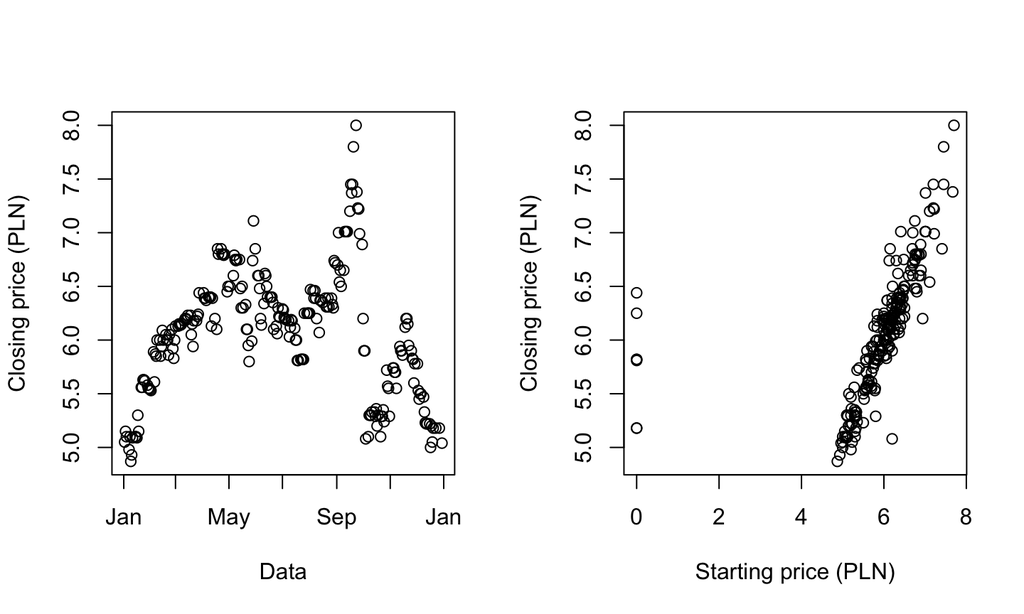

```r
par(mfrow=c(1,2))
plot(stock_data$Kurs.zamkniecia~stock_data$Data, xlab="Data", ylab="Closing price (PLN)")
plot(stock_data$Kurs.zamkniecia~stock_data$Kurs.otwarcia, xlab="Starting price (PLN)", ylab="Closing price (PLN)")
```

```r
#plot(stock_data$Kurs.zamkniecia~stock_data$Wolumen.obrotu, xlab="Trading volume", ylab="Closing price (PLN)")
#plot(stock_data$Kurs.zamkniecia~stock_data$Kurs.maksymalny, xlab="Maximla price (PLN)", ylab="Closing price (PLN)")
```

## Aggregate data by week

```r
stock.week.avg <- as.numeric(
    aggregate(
      stock_data$Kurs.zamkniecia,
      by=list(floor((stock_data$Data-stock_data$Data[1])/7)),
      FUN=mean)$x
  )
```

## Plot the result

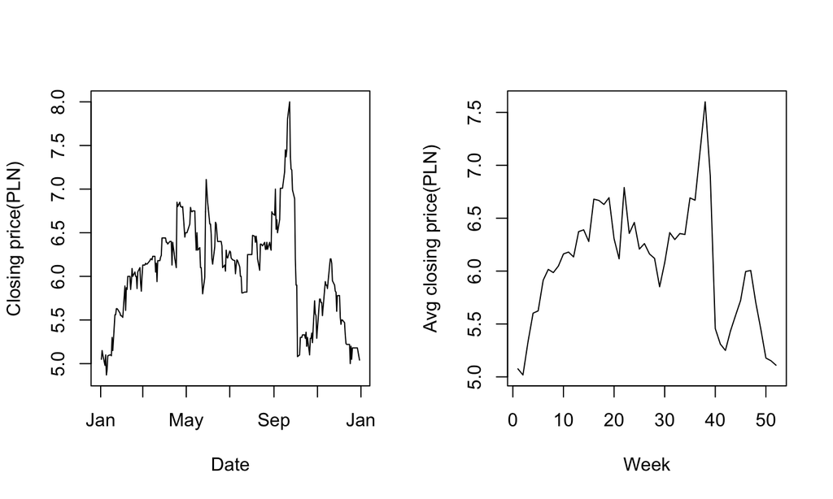

```r
par(mfrow=c(1,2))
with(stock_data, {
  plot(Kurs.zamkniecia~Data,type='l',xlab="Date",ylab="Closing price(PLN)")
})
plot(stock.week.avg,type='l',xlab="Week",ylab="Avg closing price(PLN)")
```

## Predicting avarage week price

Predicting week price base on waighted avarage from last weeks. Parameters of prediction are *weights* for avarage.

```r
predict_price <- function(weights=c(w1,w2,w3,w4), weekNum, weekAvg) {
  prediction <- 0
  weight_sum <-0
  for(i in 1:length(weights)) {
    if(weekNum>i) {
      prediction <- prediction + weights[i]*weekAvg[weekNum-i]
      weight_sum <- weight_sum + weights[i]
    }
  }
  return (prediction/weight_sum)
}
```

## Predicting avarage week price - example

Simple avarage from last 4 weeks:

```r
test_week_num <- 10
predict_price(c(1,1,1,1),test_week_num, stock.week.avg)
```

```
## [1] 5.991
```

```r
stock.week.avg[test_week_num]
```

```
## [1] 6.162
```

## Parameters evealuation

Cost function will be Mean Root Square function calculated on all dataset for given parameters (weights for our prediction).

```r
predict_eval <- function(weights=c(w1,w2,w3,w4), weekAvg = stock.week.avg){
  predictions <-as.numeric(lapply(4:length(weekAvg),
                    FUN=function(w) predict_price(weights,w,weekAvg)
                  )
                )

  ## data normalization!
  max_val=max(abs(c(weekAvg[-(1:3)],predictions)))
  return(sqrt(mean((weekAvg[-(1:3)]/max_val-predictions/max_val)^2)))
}
```

## Finding best weights

Optimization task -> [CRAN Task View: Optimization and Mathematical Programming](http://cran.r-project.org/web/views/Optimization.html)

To find weights for our prediction which best fits the model we us one of metaheuristic algorithm: **Particle Swarm Optimization** from package **pso**.

```r
install.packages('pso')
?pso::psoptim
```

[figure not shown]

## Particle Swarm Optimization

- optimizes a problem by iteratively trying to improve a candidate solution
- population -> swarm, candidate solutions -> called particles
- movements of the particles are guided by their own best known position in the search-space as well as the entire swarm's best known position
- example visualization: http://vimeo.com/17407010
- nice lecture about stochastic optimization https://www.youtube.com/watch?v=C3jyhZhyNE4

## Running optimizer

```r
library(pso)
#random initial weights
init_weights=runif(4,0,1)
result_pso<-psoptim(init_weights, predict_eval, gr=NULL, stock.week.avg,
                 lower=rep(0,length(init_weights)),
                 upper=rep(1,length(init_weights)),
                 control=list(maxit=100,type='SPSO2011',
                              reltol=1e-8,vectorize=TRUE))

result_pso$par #best weights
```

```
## [1] 0.95323845 0.00000000 0.00000000 0.01758434
```

```r
result_pso$value #minimal cost(eval) function
```

```
## [1] 0.0424164
```

## PSO Result visualization

### Helping function

```r
all_week_predictions<-function(par,weekAvg=stock.week.avg) {
  return (as.numeric(lapply(
    2:length(weekAvg),
    FUN=function(n) predict_price(par,n,weekAvg)
  )))
}
```

## PSO Result visualization - Plot

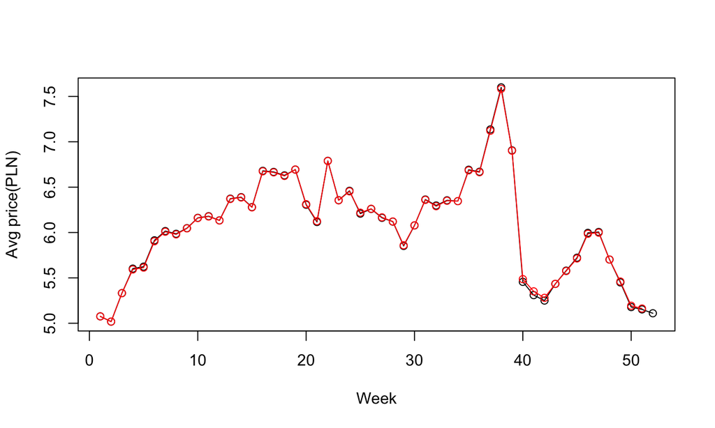

```r
plot(stock.week.avg,type='o',
     ylim=c(min(stock.week.avg),max(stock.week.avg)),xlab="Week",ylab="Avg price(PLN)")
pso_predictions <- all_week_predictions(result_pso$par)
points(pso_predictions,type='o',col='red')
```

## PSO Result visualization - With dummy (1,1,1,1) prediction

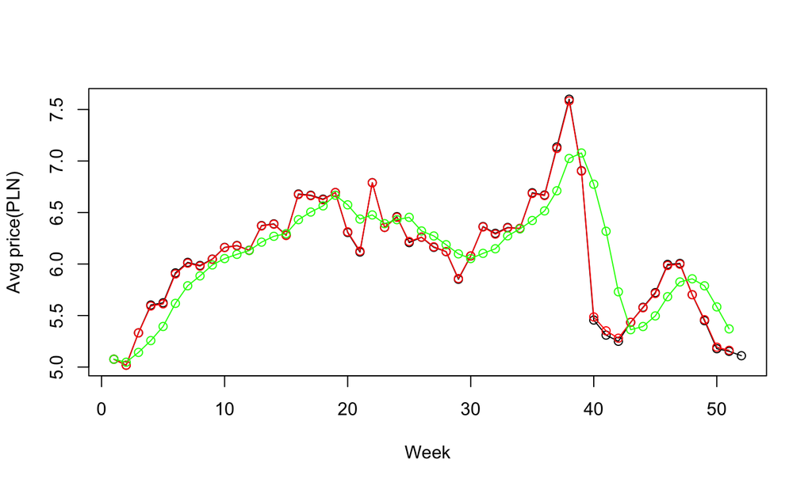

```r
dummy_predictions <- all_week_predictions(c(1,1,1,1))
points(dummy_predictions,type='o',col='green')
```

## Simulated annealing (stats::optim)

```r
init_weights=runif(4,0,1)
result_sa <- optim(init_weights, predict_eval, gr=NULL, stock.week.avg,
                   method = "SANN",
                   control = list(maxit = 10000, temp = 10000, #trace=TRUE,
                                  REPORT = 0, tmax=10)
)
```

```r
result_sa$par
```

```
## [1]  1.99473513 -0.09098583 -0.15103808 -0.09207642
```

```r
result_sa$value
```

```
## [1] 0.0426211
```

## Simulated annealing - Plot

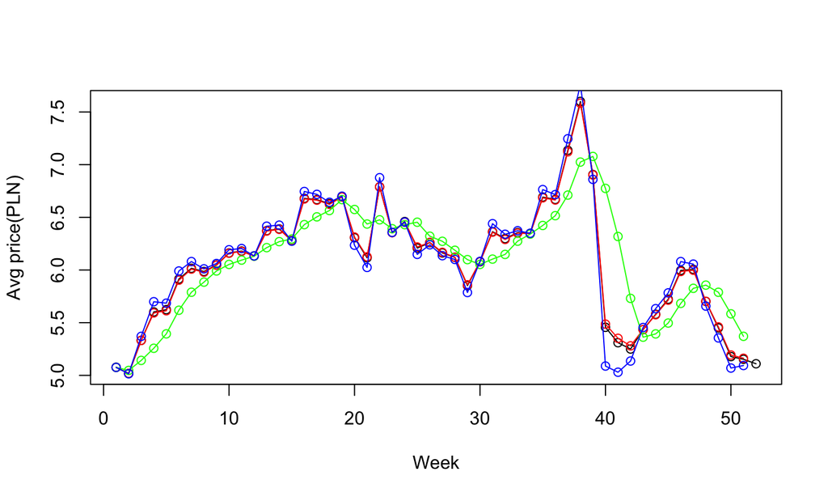

## Genetic Algorithms (GA::ga)

```r
require(GA)
init_weights=runif(4,0,1)

result_ga <- ga("real-valued", predict_eval, stock.week.avg,
                min=rep(0,length(init_weights)),
                max=rep(1,length(init_weights)),
                maxiter = 1000
                )
```

[output not shown]

[output cut: 945 more lines]

[output not shown]

```r
result_ga@solution
```

```
##              x1          x2          x3        x4
## [1,] 0.00534597 0.007909179 0.003882974 0.9465177
```

## Genetic Algorithms - Plot

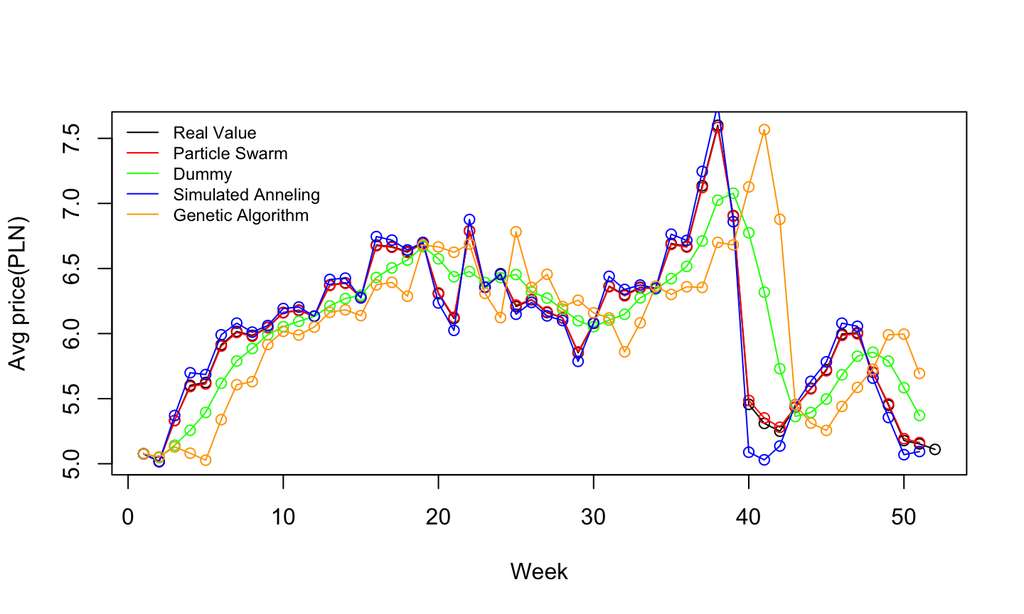